# Dr Feyishayo Olukoya PhD, MMath, FHEA

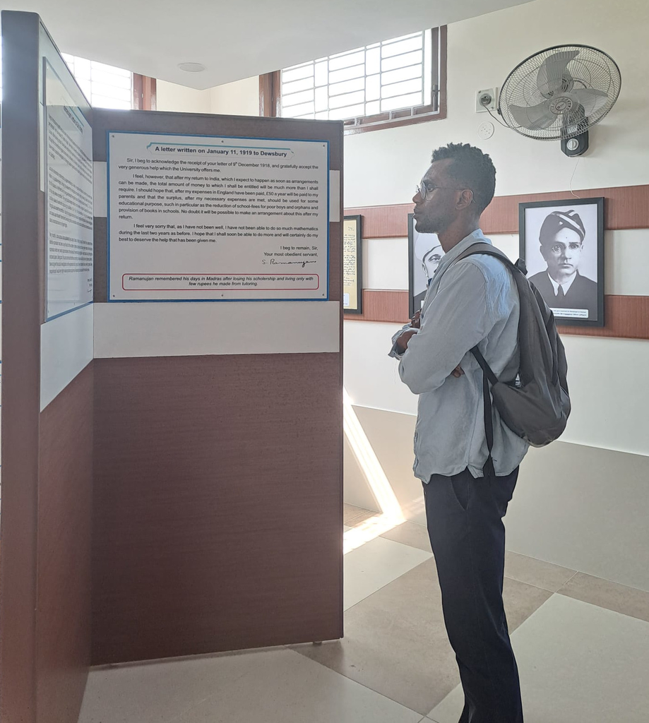

**Feyishayo Olukoya**  
School of Mathematics and Statistics  
University of St Andrews  
North Haugh  
St Andrews  
Fife  
Scotland  
KY16 9SS  
Email: **feyisayo.olukoya1@abdn.ac.uk**  
Email: **feyisayo.olukoya@gmail.com**  
**Curriculum Vitae**

**Trivia**

Erdős number: 2  
Olukoya—Cameron—Erdős

## About me

I am a Research Fellow at the University of Aberdeen and holder of the Engineering and Physical Sciences Research Council Fellowship “The Higman-Thompson groups, their generalisations, and automorphisms of shift spaces” that investigates the interplay between (generalisations) of the Higman-Thompson groups and shift dynamical systems.

In December 2018, I obtained my PhD in pure mathematics at the University of St Andrews. This was funded by the [Carnegie Trust for the Universities of Scotland](https://carnegie-trust.org/) and was supervised by of [Dr. Collin Bleak](https://www.st-andrews.ac.uk/mathematics-statistics/people/cb211/) and [Dr. Martyn Quick](https://martynquick.github.io/index.html). Since then I have been a postdoctoral research fellow working in geometric and combinatorial group theory at the [Institute of Mathematics](https://www.abdn.ac.uk/ncs/departments/mathematics/) at the University of Aberdeen (2018-2020); an LMS Early Career Fellow and then an Associate Lecturer in the School of Mathematics and Statistics at the University of St Andrews (2020-2022). Over the course of the latter position, I attained Fellowship of the Higher Education Academy and while at the University of Aberdeen, I was nominated for a teaching excellence award.

I was previosuly a lecturer in mathematics at [Keele University](https://www.keele.ac.uk/)

#### YouTube channel

I have a [YouTube channel](https://www.youtube.com/@shayoolukoya8900/videos) where I look at miscellaneous mathematics (and related) topics often emphasing, where possible, a non-western point of view. This is partly funder by the *Engineering and Physical Sciences Research Council Open postdoctoral fellowship “The Higman-Thompson groups, their generalisations, and automorphisms of shift spaces.”* Below is a sample video.

[video not shown]

Back to top